# Assignment 3 - Web Scrapping and Text Mining

Brandyn Ruiz

10/14/2020

```r
library(stringr)
library(httr)
library(readr)
library(tidytext)
library(tidyr)
library(dplyr)
library(forcats)
library(ggplot2)
```

# APIs

Using the [NCBI API](https://www.ncbi.nlm.nih.gov/home/develop/api/), look for papers that show up under the term ‘sars-cov-2 trial vaccine’. Look for the data in the pubmed database, and the retreive the details of the paper as shown in lab 7. How many papers were you able to find?

```r
# Downloading the website
website <- xml2::read_html("https://pubmed.ncbi.nlm.nih.gov/?term=sars-cov-2+trial+vaccine")

# Finding the counts
counts <- xml2::xml_find_first(website, "/html/body/main/div[9]/div[2]/div[2]/div[1]/span")

# Turning it into text
counts <- as.character(counts)

# Extracting the data using regex
stringr::str_extract(counts, "[0-9,]+")
```

```
## [1] "564"
```

There are 564 papers currently about the sars-cov-2 trial vaccines.

Using the list of pubmed ids you retrieved, download each papers’ details using the query parameter rettype = abstract. If you get more than 250 ids, just keep the first 250.

```r
query_ids <- GET(
  url   = "https://eutils.ncbi.nlm.nih.gov/entrez/eutils/esearch.fcgi",
  query = list(db = 'pubmed', term = 'sars-cov-2 trial vaccine', retmax = 250))

# Extracting the content of the response of GET
ids <- httr::content(query_ids)

# Turn the result into a character vector
ids <- as.character(ids)
cat(ids)
```

[output not shown]

[output cut: 288 more lines]

[output not shown]

```r
# Find all the ids
ids <- stringr::str_extract_all(ids, "<Id>[0-9]+</Id>")[[1]]

# Remove all the leading and trailing <Id> </Id>. Make use of "|"
ids <- stringr::str_remove_all(ids, "<Id>|</Id>")
```

```r
publications <- GET(
  url   = "https://eutils.ncbi.nlm.nih.gov/entrez/eutils/efetch.fcgi",
  query = list(db = 'pubmed', id = paste(ids, collapse = ','), retmax = 250, rettype = 'abstract'))

# Turning the output into character vector
publications <- httr::content(publications)
publications_txt <- as.character(publications)

pub_char_list <- xml2::xml_children(publications)
pub_char_list <- sapply(pub_char_list, as.character)
```

```r
abstracts <- str_extract(pub_char_list, "<Abstract>(\\n|.)+</Abstract>")
abstracts <- str_remove_all(abstracts, "</?[[:alnum:]]+>")
abstracts <- str_replace_all(abstracts, "\\s+", " ")

table(is.na(abstracts))
```

```
##
## FALSE  TRUE
##   167    62
```

```r
titles <- str_extract(pub_char_list, "<ArticleTitle>(\\n|.)+</ArticleTitle>")
titles <- str_remove_all(titles, "</?[[:alnum:]]+>")
titles <- str_replace_all(titles, "\\s+", " ")
```

```r
# Extracts Publication Date
year <- str_extract(pub_char_list, "<Year>[0-9,]+</Year>")
month <- str_extract(pub_char_list, "<Month>[[:alpha:]]+</Month>")
day <- str_extract(pub_char_list, "<Day>[0-9,]+</Day>")

# Removes year, month, day tabs
year <- str_remove_all(year, "<Year>|</Year>")
month <- str_remove_all(month, "<Month>|</Month>")
day <- str_remove_all(day, "<Day>|</Day>")

table(is.na(year))
```

```
##
## FALSE
##   229
```

```r
table(is.na(month))
```

```
##
## FALSE  TRUE
##    96   133
```

```r
table(is.na(day))
```

```
##
## FALSE
##   229
```

```r
Pubdate <- paste(month, day, year, sep = ' ')
```

```r
database <- data.frame(PubMedID = ids, PubDate = Pubdate, Title = titles, Abstracts = abstracts)

knitr::kable(database)
```

| PubMedID | PubDate | Title | Abstracts |
| --- | --- | --- | --- |
| 33043110 | Oct 13 2020 | EXPLORING SURFACE GLYCOPROTEIN TO DESIGN MULTI-EPITOPE VACCINE AGAINST COVID-19. | Stimulation and generation of T and B cell mediated long-term immune response is essential for the curbing of a deadly virus such as SAR-CoV-2. Immunoinformatics approach in vaccine design takes advan… |
| 33042591 | Sep 13 2020 | Impact of COVID-19 on clinical trials and clinical research: A systematic review. | Background: The World Health Organization has reported more than 31,186,000 confirmed cases of coronavirus disease-19 (COVID-19), including 962,343 deaths, worldwide as on September 21, 2020. The curr… |
| 33038433 | Oct 12 2020 | COVID-19: discovery, diagnostics and drug development. | An epidemic of acute respiratory syndrome (Covid-19) started in humans in Wuhan in 2019, and became a pandemic. Groups from China Identified and sequenced the virus responsible for COVID-19, named SAR… |
| 33022293 | Oct 09 2020 | Clinical trial protocols of repurposed prophylaxis for COVID-19: a review. | Efficient therapeutic strategies are needed to counter the COVID-19 pandemic, caused by the SARS-CoV-2 virus. In a context where specific vaccines are not yet available, the containment of the pandemi… |
| 33013255 | Sep 06 2020 | Screening of FDA Approved Drugs Against SARS-CoV-2 Main Protease: Coronavirus Disease. | At the end of December 2019, a new strain of coronavirus was identified in the Wuhan city of Hubei province in China. Within a shorter period of time, an unprecedented outbreak of this strain was witn… |
| 33012348 | NA 09 2020 | SARS-CoV-2 Vaccine Development: Current Status. | In the midst of the severe acute respiratory syndrome coronavirus 2 pandemic and its attendant morbidity and mortality, safe and efficacious vaccines are needed that induce protective and long-lived i… |
| 32998488 | NA 07 2020 | Status of COVID-19 vaccine development. | NA |
| 32998157 | Sep 15 2020 | COVID-19 vaccine BNT162b1 elicits human antibody and TH1 T cell responses. | An effective vaccine is needed to halt the spread of the severe acute respiratory syndrome coronavirus-2 (SARS-CoV-2) pandemic. Recently, we reported safety, tolerability and antibody response data fr… |
| 32997699 | NA 07 2020 | Analysis of COVID-19 clinical trials: A data-driven, ontology-based, and natural language processing approach. | With the novel COVID-19 pandemic disrupting and threatening the lives of millions, researchers and clinicians have been recently conducting clinical trials at an unprecedented rate to learn more about… |
| 32994572 | NA 05 2020 | COVID vaccine confidence requires radical transparency. | NA |
| 32991794 | Sep 29 2020 | Safety and Immunogenicity of SARS-CoV-2 mRNA-1273 Vaccine in Older Adults. | Testing of vaccine candidates to prevent infection with severe acute respiratory syndrome coronavirus 2 (SARS-CoV-2) in an older population is important, since increased incidences of illness and deat… |
| 32988688 | NA 13 2020 | Intention to participate in a COVID-19 vaccine clinical trial and to get vaccinated against COVID-19 in France during the pandemic. | The world is facing the COVID-19 pandemic. The development of a vaccine is challenging. We aimed to determine the proportion of people who intend to get vaccinated against COVID-19 in France or to par… |
| 32985963 | Sep 28 2020 | Coronavirus Disease 2019 Vaccine Development: An Overview. | To this day, the coronavirus disease 2019 (COVID-19) pandemic has not shown signs of abating. Moreover, the virus responsible for the pandemic, severe acute respiratory syndrome coronavirus 2, has evo… |
| 32979327 | NA 13 2020 | The arrival of Sputnik V. | NA |
| 32978611 | NA 05 2020 | COVID-vaccine results are on the way - and scientists’ concerns are growing. | NA |
| 32974268 | NA 28 2020 | Overview of the First 6 Months of Clinical Trials for COVID-19 Pharmacotherapy: The Most Studied Drugs. | SARS-CoV-2 rapidly spread from China until it was defined a pandemic by WHO in March 2020. Related scientific papers have rapidly extended information regarding the diagnosis, treatment and epidemiolo… |
| 32973779 | NA 14 2020 | The 2020 Pandemic: Current SARS-CoV-2 Vaccine Development. | Coronaviruses are enveloped viruses with a positive-sense single-stranded RNA genome infecting animals and humans. Coronaviruses have been described more than 70 years ago and contain many species. Se… |
| 32969973 | NA 13 2020 | Coronavirus disease-19 vaccine development utilizing promising technology. | Coronavirus disease-19 (COVID-19) is a highly transmittable and pathogenic pneumonia-causing disease, which is caused by severe acute respiratory syndrome coronavirus-2, resulting in millions of death… |
| 32969369 | Sep 01 2020 | Safety and Efficacy of Different Therapeutic Interventions on Prevention and Treatment of COVID-19. | Severe acute respiratory syndrome coronavirus 2 (SARS-CoV-2) is the strain of coronavirus that causes coronavirus disease 2019 (COVID-19), a respiratory illness. COVID-19 has now become a global publi… |
| 32967006 | Sep 01 2020 | SARS-CoV-2 vaccines in development. | Severe acute respiratory syndrome coronavirus 2 (SARS-CoV-2) was first reported in late 2019 in China and is the causative agent of the coronavirus disease 2019 (COVID-19) pandemic. To mitigate the ef… |
| 32963672 | NA 30 2020 | Expedited COVID-19 vaccine trials: a rat-race with challenges and ethical issues. | The intense global efforts are directed towards development of vaccines to halt the COVID-19 virus pandemic. There are 160 candidate vaccines under clinical trials across the world using different mol… |
| 32958009 | NA 02 2020 | The use of mesenchymal stromal cells in the treatment of coronavirus disease 2019. | More than seven months into the coronavirus disease -19 (COVID-19) pandemic, infection from the severe acute respiratory syndrome coronavirus-2 (SARS-CoV-2) has led to over 21.2 million cases and resu… |
| 32943115 | Sep 23 2020 | Using BCG vaccine to enhance non-specific protection of health care workers during the COVID-19 pandemic: A structured summary of a study protocol for a randomised controlled trial in Denmark. | The Bacille Calmette-Guérin (BCG) vaccine against tuberculosis is associated with non- specific protective effects against other infections, and significant reductions in all-cause morbidity and morta… |
| 32934758 | NA 24 2020 | Tuberculosis and COVID-19: Lessons from the Past Viral Outbreaks and Possible Future Outcomes. | The threat of contagious infectious diseases is constantly evolving as demographic explosion, travel globalization, and changes in human lifestyle increase the risk of spreading pathogens, leading to … |
| 32934375 | NA 28 2020 | Researchers highlight ‘questionable’ data in Russian coronavirus vaccine trial results. | NA |
| 32933536 | NA 02 2020 | Pathophysiology and treatment strategies for COVID-19. | The outbreak of Coronavirus disease of 2019 (COVID-19) caused by the Severe Acute Respiratory Syndrome coronavirus 2 (SARS-CoV-2), has posed a serious health threat. The increasing number of COVID-19 … |
| 32929259 | NA 23 2020 | Scientists relieved as coronavirus vaccine trial restarts - but question lack of transparency. | NA |
| 32918548 | Sep 09 2020 | Multicenter interim guidance on use of antivirals for children with COVID-19/SARS-CoV-2. | Although Coronavirus Disease 2019 (COVID-19) is a mild infection in most children, a small proportion develop severe or critical illness. Data evaluating agents with potential antiviral activity conti… |
| 32918053 | NA 28 2020 | China’s coronavirus vaccine shows military’s growing role in medical research. | NA |
| 32908297 | NA 23 2020 | The underdog coronavirus vaccines that the world will need if front runners stumble. | NA |

[output cut: 199 more lines]

# Text Mining

A new dataset has been added to the data science repository (https://github.com/USCbiostats/data-science-data/tree/master/03_pubmed). The dataset contains 3241 abstracts from articles across 5 search terms. Your job is to analyse these abstracts to find interesting insights.

1. Tokenise the abstracts and count the number of each token. Do you see anythnig interesting? Does removing stop words change what tokens appear as the most frequent? What are the 5 most common token for each search term after removing stopwords?

```r
pubmed <- read_csv("https://raw.githubusercontent.com/USCbiostats/data-science-data/master/03_pubmed/pubmed.csv")

pubmed%>%
  unnest_tokens(token, abstract)%>%
  count(token)%>%
  top_n(20, n)
```

```
## # A tibble: 20 x 2
##    token        n
##    <chr>    <int>
##  1 19        7080
##  2 a         8245
##  3 and      19993
##  4 are       2833
##  5 as        3159
##  6 cancer    3999
##  7 covid     7275
##  8 for       5492
##  9 in       14653
## 10 is        5649
## 11 of       24760
## 12 patients  4674
## 13 prostate  3832
## 14 that      3226
## 15 the      28126
## 16 this      3158
## 17 to       10920
## 18 was       3315
## 19 were      3226
## 20 with      8038
```

The token words within the abstracts do not tell us a lot of information, as they are the most commonly used words.

```r
 # Removing Stop Words
pubmed%>%
  unnest_tokens(token, abstract)%>%
  anti_join(stop_words, by = c('token' = 'word'))%>%
  filter(!(token %in% as.character(seq(0, 100))))%>%
  count(token)%>%
  top_n(5, n)
```

```
## # A tibble: 5 x 2
##   token        n
##   <chr>    <int>
## 1 cancer    3999
## 2 covid     7275
## 3 disease   2574
## 4 patients  4674
## 5 prostate  3832
```

Removing the stop words and numerical characters changes the words that are most frequent and we have more of a definition of the abstracts. With the 5 most commonly used words being cancer, covid, disease, patients, and prostate.

2. Tokenize the abstracts into bigrams. Find the 10 most common bigram and visualize them with ggplot2

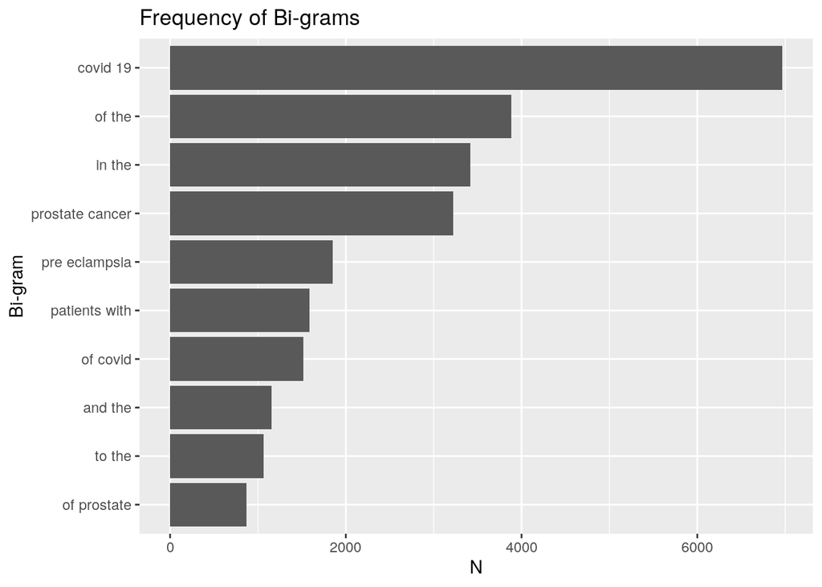

```r
pubmed%>%
  unnest_ngrams(ngram, abstract, n = 2)%>%
  count(ngram, sort = TRUE)%>%
  top_n(10, n)%>%
  ggplot(aes(x = n, y = fct_reorder(ngram, n)))+
  geom_col()+
  labs(title = 'Frequency of Bi-grams', x = 'N', y = 'Bi-gram')
```

3. Calculate the TF-IDF value for each word-search term combination. (here you want the search term to be the “document”) What are the 5 tokens from each search term with the highest TF-IDF value? How are the results different from the answers you got in question 1?

```r
pubmed%>%
  unnest_tokens(abstract, abstract)%>%
  count(abstract, term)%>%
  bind_tf_idf(abstract, term, n)%>%
  top_n(5, tf_idf)
```

```
## # A tibble: 5 x 6
##   abstract     term                n      tf   idf tf_idf
##   <chr>        <chr>           <int>   <dbl> <dbl>  <dbl>
## 1 covid        covid            7275 0.0371   1.61 0.0597
## 2 eclampsia    preeclampsia     2005 0.0143   1.61 0.0230
## 3 meningitis   meningitis        429 0.00919  1.61 0.0148
## 4 preeclampsia preeclampsia     1863 0.0133   1.61 0.0214
## 5 prostate     prostate cancer  3832 0.0312   1.61 0.0502
```

```r
# Top 5 TF-IDF by term
pubmed%>%
  unnest_tokens(abstract, abstract)%>%
  count(abstract, term)%>%
  bind_tf_idf(abstract, term, n)%>%
  arrange(desc(tf_idf))%>%
  group_by(term)%>%
  top_n(5, tf_idf)
```

```
## # A tibble: 25 x 6
## # Groups:   term [5]
##    abstract     term                n      tf   idf  tf_idf
##    <chr>        <chr>           <int>   <dbl> <dbl>   <dbl>
##  1 covid        covid            7275 0.0371  1.61  0.0597
##  2 prostate     prostate cancer  3832 0.0312  1.61  0.0502
##  3 eclampsia    preeclampsia     2005 0.0143  1.61  0.0230
##  4 preeclampsia preeclampsia     1863 0.0133  1.61  0.0214
##  5 meningitis   meningitis        429 0.00919 1.61  0.0148
##  6 cf           cystic fibrosis   625 0.0127  0.916 0.0117
##  7 fibrosis     cystic fibrosis   867 0.0176  0.511 0.00901
##  8 cystic       cystic fibrosis   862 0.0175  0.511 0.00896
##  9 meningeal    meningitis        219 0.00469 1.61  0.00755
## 10 pandemic     covid             800 0.00408 1.61  0.00657
## # … with 15 more rows
```

```r
covid <- c('covid', 'pandemic', 'coronavirus', 'sars', 'cov')
prostate <- c('prostate', 'androgen', 'psa', 'prostatectomy', 'castration')
preeclampsia <- c('eclampsia', 'preeclampsia', 'pregancy', 'maternal', 'gestational')
meningitis <- c('meningitis', 'meningeal', 'pachymeningitis', 'csf', 'meninges')
cystic <- c('cf', 'fibrosis', 'cystic', 'cftr', 'sweat')

listing <- rbind(covid, prostate, preeclampsia, meningitis, cystic)
listing <- data.frame(listing)
knitr::kable(listing)
```

|  | X1 | X2 | X3 | X4 | X5 |
| --- | --- | --- | --- | --- | --- |
| covid | covid | pandemic | coronavirus | sars | cov |
| prostate | prostate | androgen | psa | prostatectomy | castration |
| preeclampsia | eclampsia | preeclampsia | pregancy | maternal | gestational |
| meningitis | meningitis | meningeal | pachymeningitis | csf | meninges |
| cystic | cf | fibrosis | cystic | cftr | sweat |

Here is a table with all the terms of `pubmed` with the 5 most tokens with the highest TF-IDF. These tokens are so different from our ones in answer 1 because these tokens are the most frequent by each specific term.